# Лабораторная работа №1

Дисциплина: Сетевые технологии

БАХИ СИДИ АЛИ ТЕМАССИНИ

1032234211@pfur.ru

Российский университет дружбы народов

2026-03-05

# Информация

## Докладчик

- БАХИ СИДИ АЛИ ТЕМАССИНИ
- Студент 3 курса
- Факультет: Фундаментальная информатика и информационные технологии
- Российский университет дружбы народов
- Email: 1032234211@pfur.ru
- GitHub: https://github.com/sidiali2030/study_2025-2026_nettech

## Цели и задачи

- Изучение методов кодирования и модуляции сигналов в Octave
- Определение спектра и параметров сигнала
- Демонстрация принципов амплитудной модуляции
- Исследование свойства самосинхронизации сигнала

# Выполнение лабораторной работы

# Построение графиков в Octave

## График y1

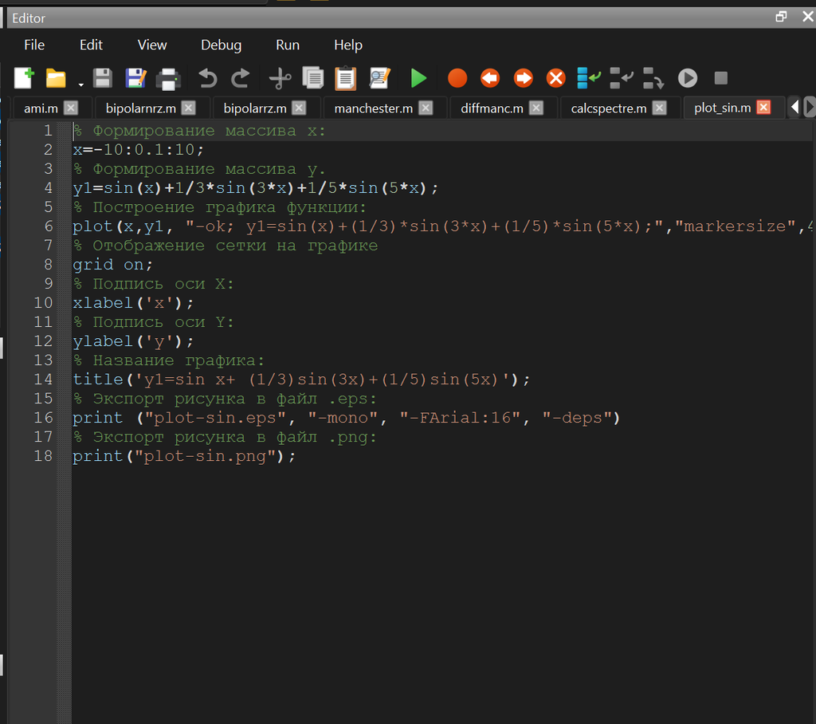

Листинг файла plot_sin.m

## График y1

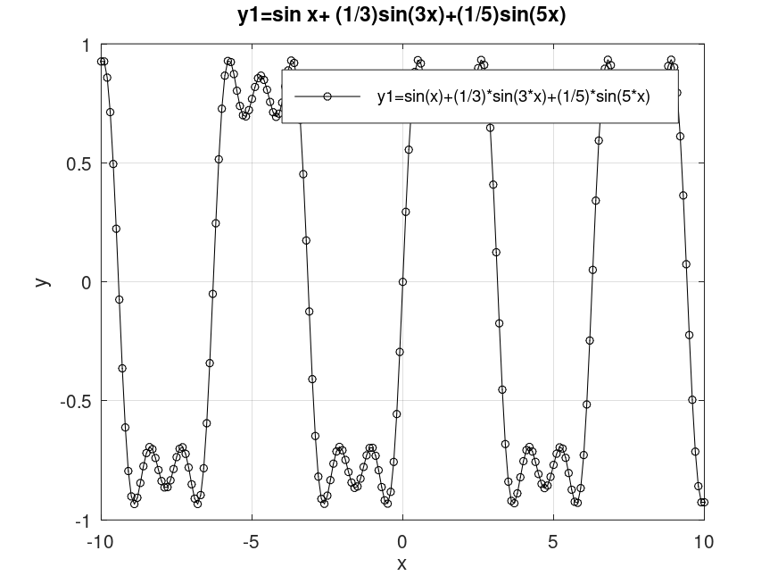

График функций y1 на интервале −10; 10

## Проверка файлов

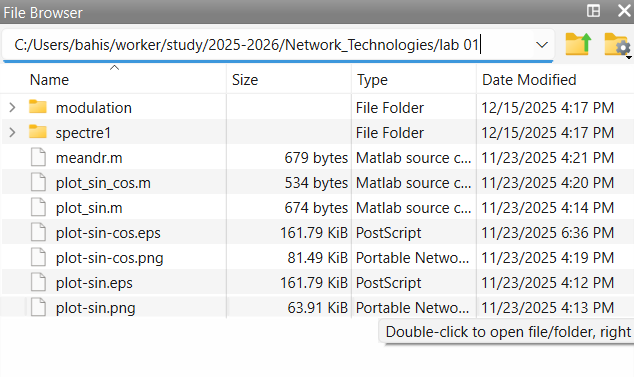

Файлы .eps, .png

## Графики у1 и у2

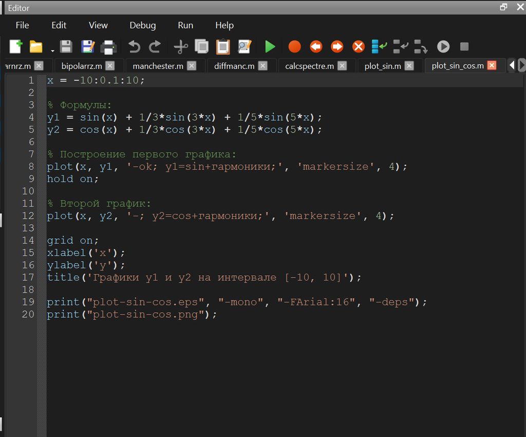

Листинг файла plot_sin_cos.m

## Графики у1 и у2

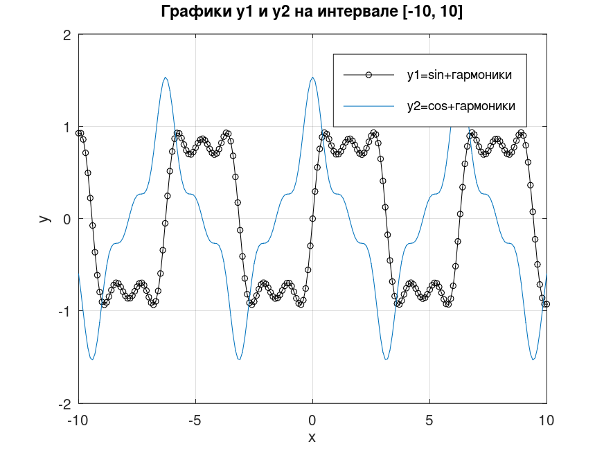

График функций y1 и y2 на интервале −10; 10

# Разложение импульсного сигнала в частичный ряд Фурье

## Меандр через косинус

- Создадим новый сценарий meandr.m. В кодe зададим начальные значения. Вычислим амплитуду гармоник и заполним массивы гармоник и элементов ряда. Далее задаём массив значений гармоник массив элементов ряда. Также экспортируем полученный график в файл в формате .png

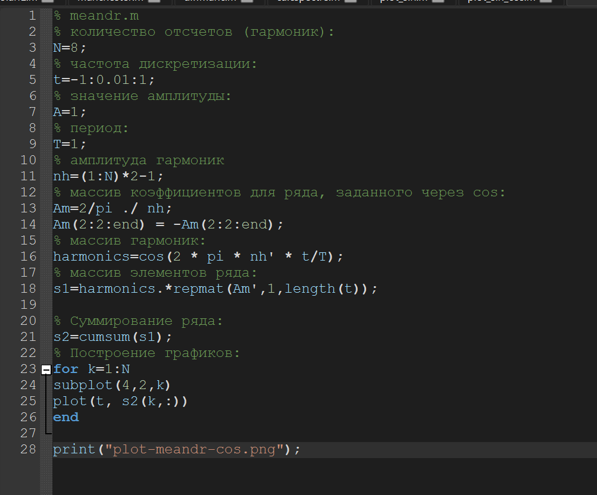

Листинг файла meandr.m

## Результат

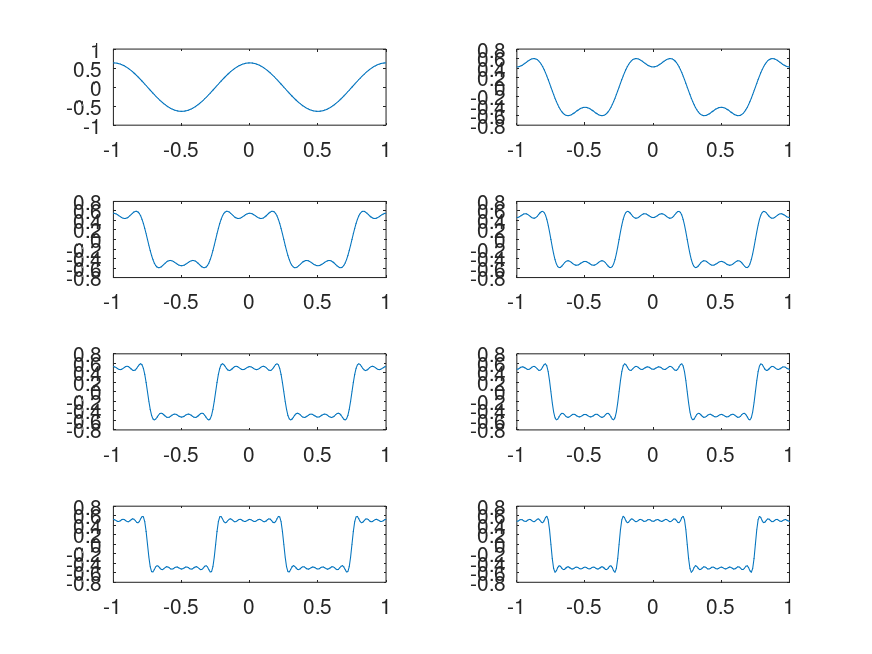

Меандр через косинусы

## Меандр через синус

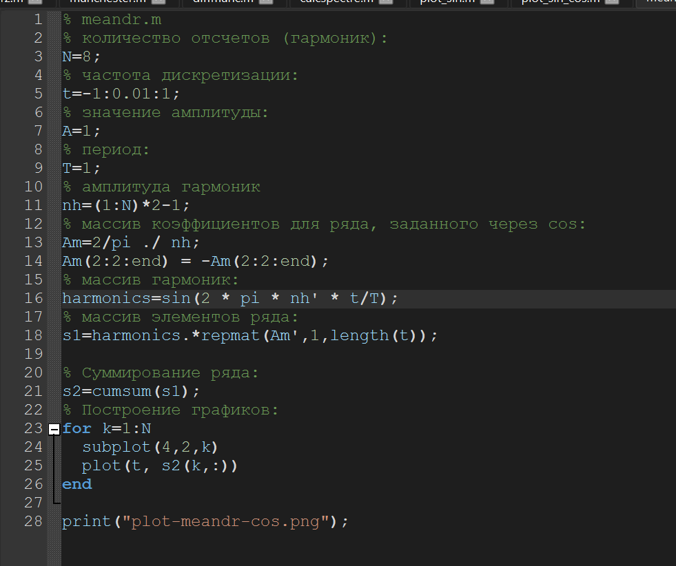

Листинг файла meandr.m

## Результат

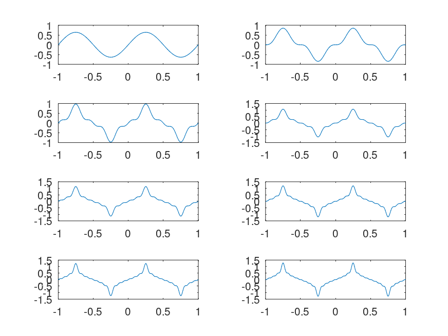

Меандр через синусы

# Определение спектра и параметров сигнала

## Сигналы разной частоты

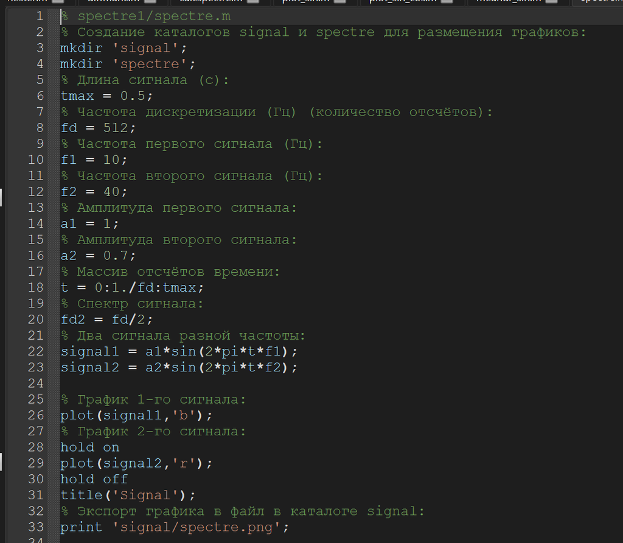

Листинг файла spectre.m

## Результат

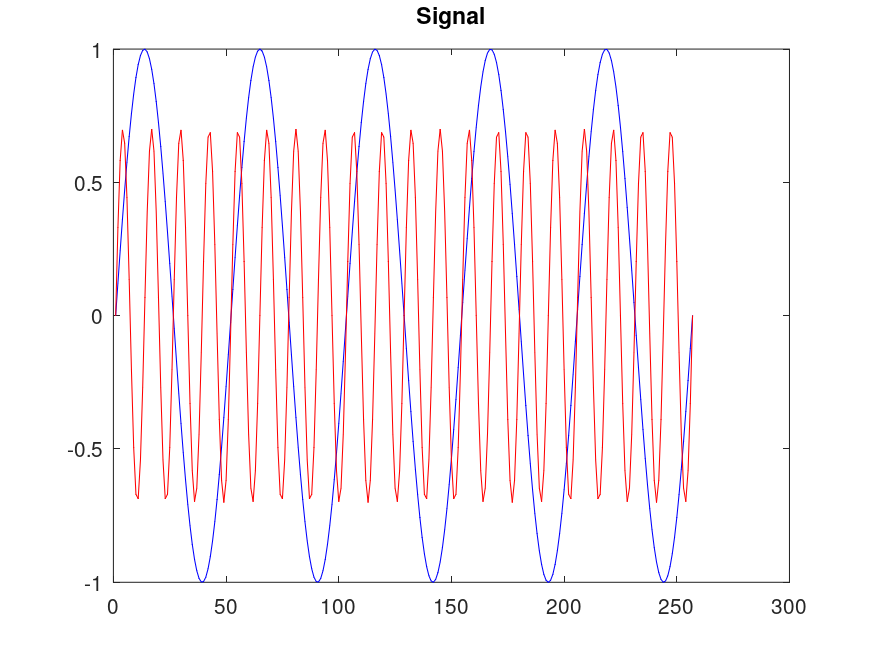

Графики сигналов разной частоты

## Спектры сигналов

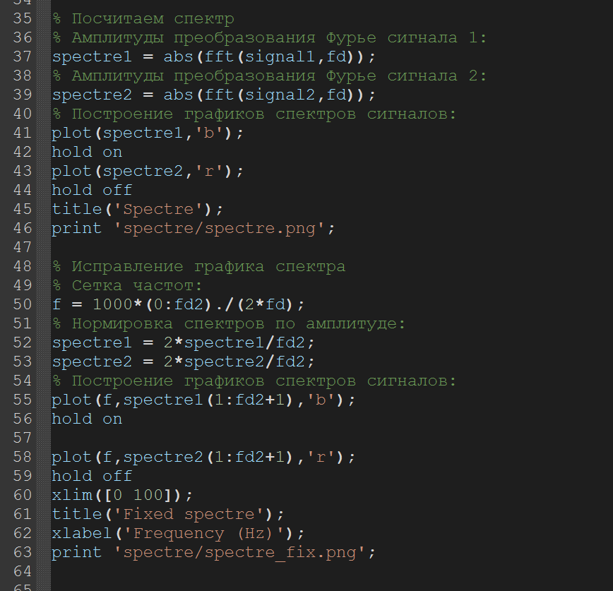

Листинг файла spectre.m

## График спектра

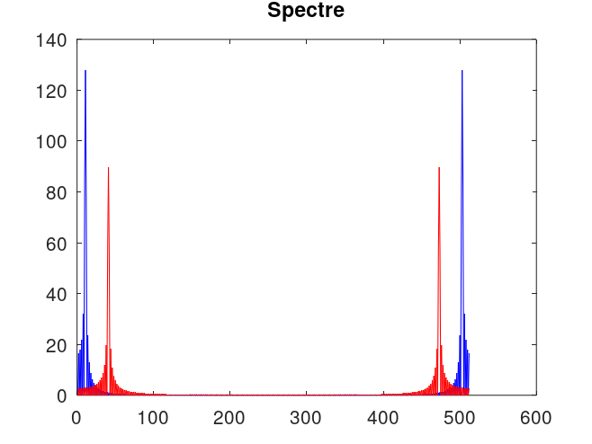

График спектра синусоидальных сигналов

## Скорректированный график

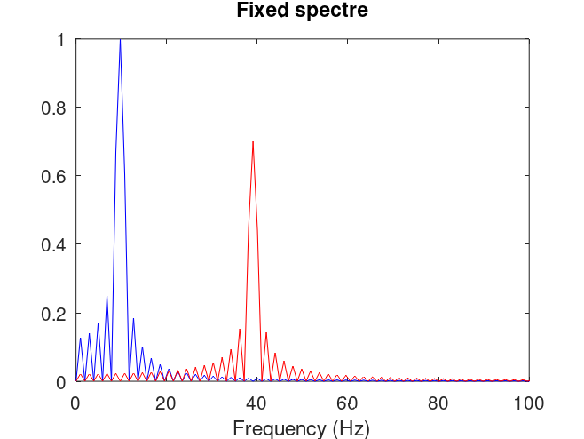

Исправленный график спектров синусоидальных сигналов

## Спектр суммы

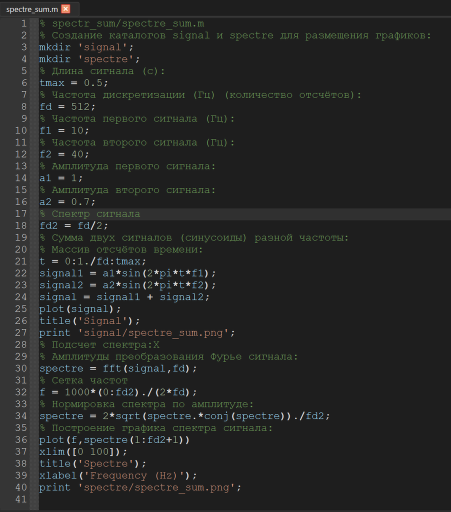

Листинг файла spectre_sum.m

## Сумма

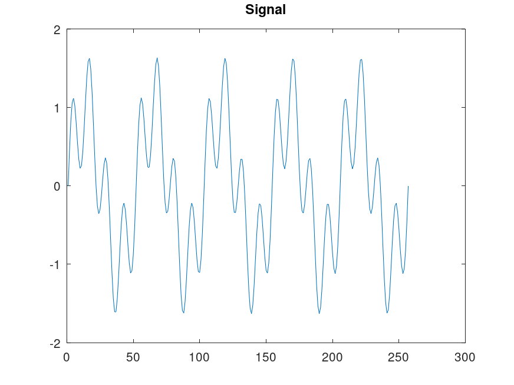

Суммарный сигнал

## Спектр суммы

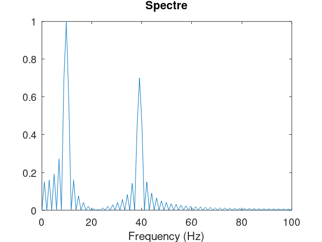

Спектр суммарного сигнала

# Амплитудная модуляция

## Амплитудная модуляция

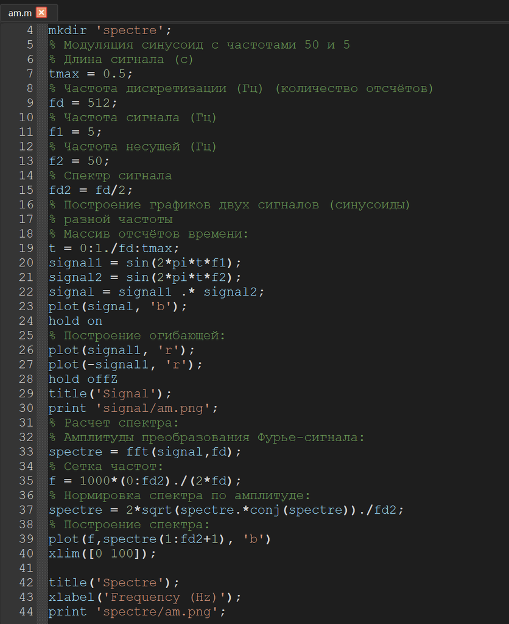

Листинг файла am.m

## Результат

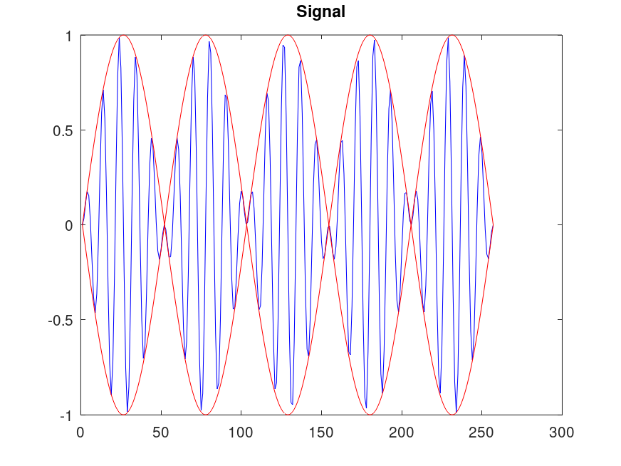

Сигнал и огибающая при амплитудной модуляции

## Результат

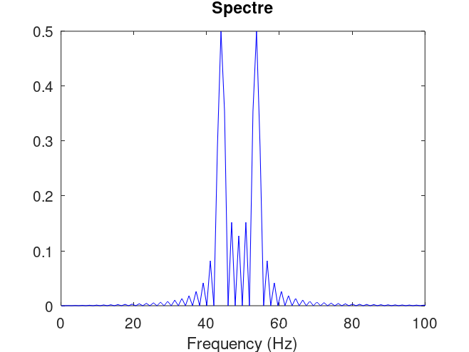

Спектр сигнала при амплитудной модуляции

# Кодирование сигнала. Исследование свойства самосинхронизации сигнала

## Подготовка

- В рабочем каталоге создадим каталог coding и в нём файлы main.m, maptowave.m, unipolar.m, ami.m, bipolarnrz.m, bipolarrz.m, manchester.m, diffmanc.m, calcspectre.m.
- В окне интерпретатора команд проверяем, установлен ли пакет расширений signal: pkg list. Так как он не установлен, то устанавливаем его: pkg list -forge и pkg install control signal

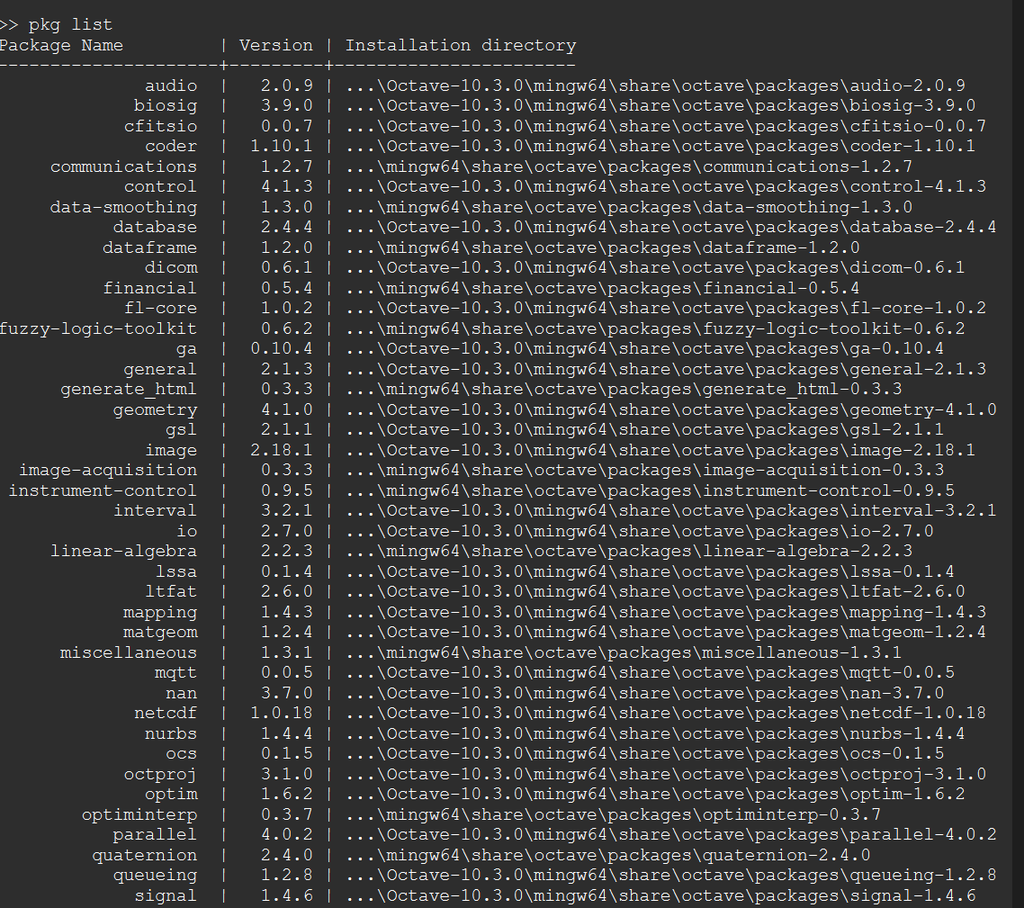

Проверка правильности установки пакета signal

## Файл main.m

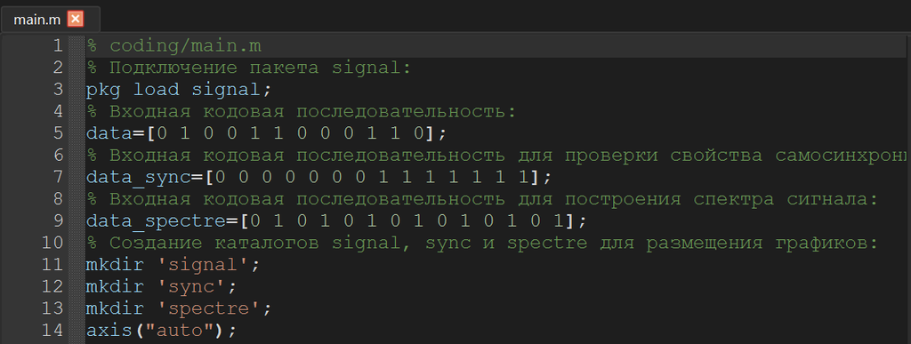

Задаем входные кодовые последовательности

## Файл main.m

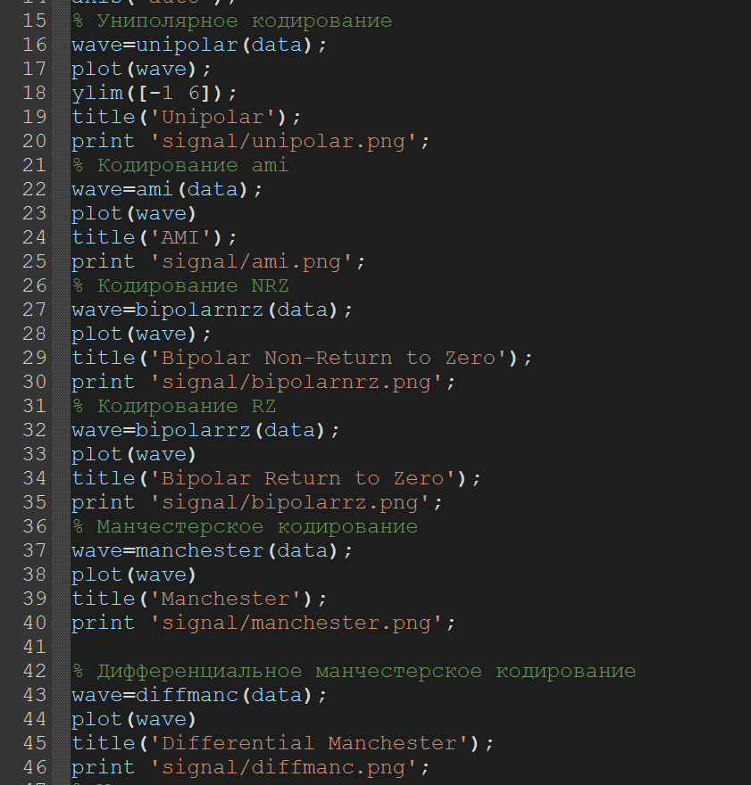

Вызовы функций для посторения модуляций кодированных сигналов кодовой последовательности data

## Файл main.m

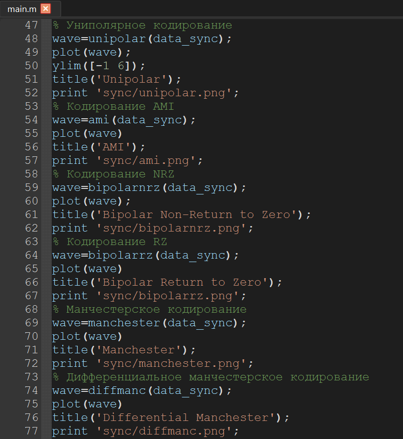

Вызовы функций для посторения модуляций кодированных сигналов кодовой последовательности data_sync

## Файл main.m

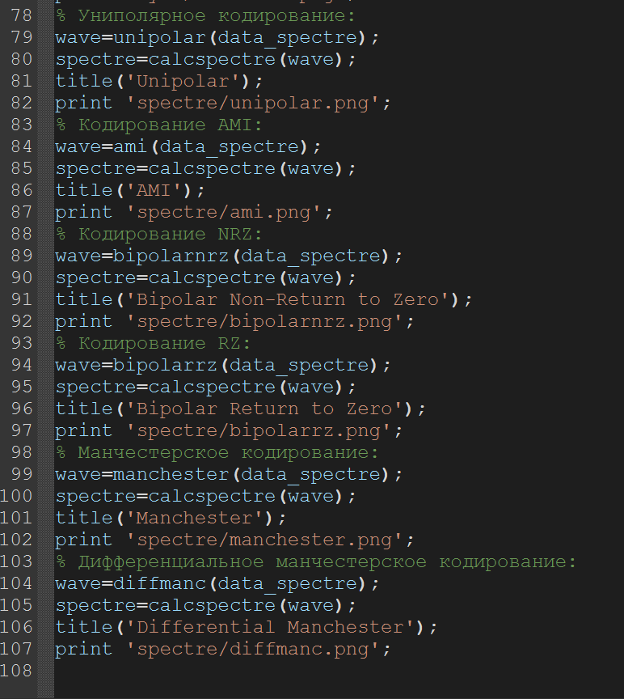

Вызовы функций для посторения графиков спектров

## Файл maptowave.m

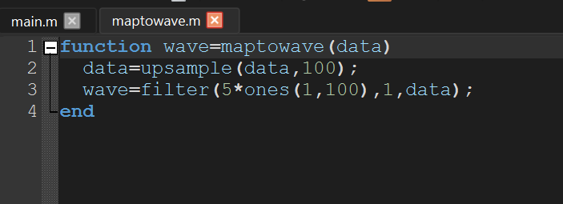

Листинг файла maptowave.m

## Файл unipolar.m

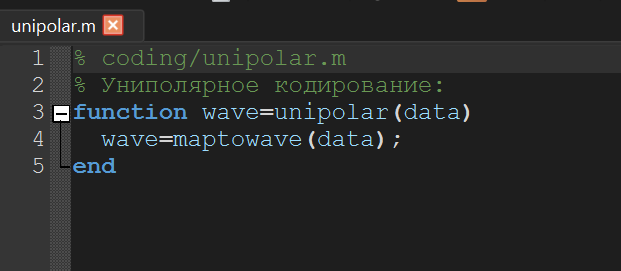

Листинг файла unipolar.m

## Файл ami.m

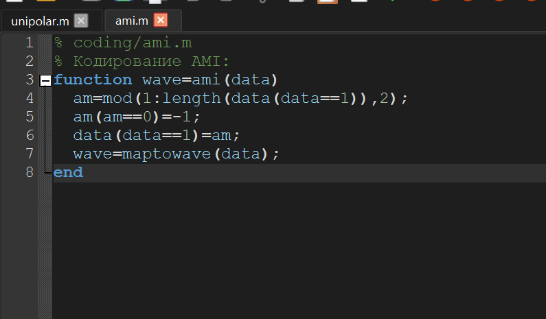

Листинг файла ami.m

## Файл bipolarnrz.m

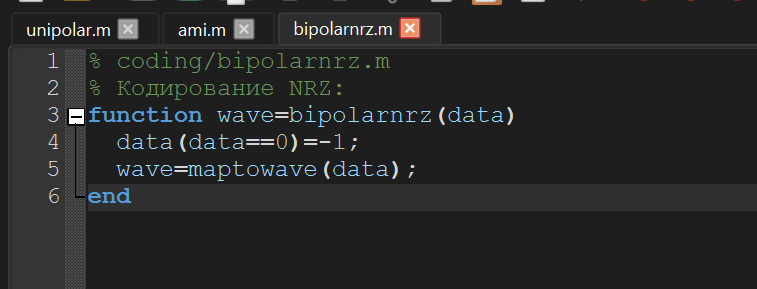

Листинг файла bipolarnrz.m